# Analyzing Individual BGG Users

Phil Henrickson

2022-01-02

# **rhyzz’s** BoardGameGeek Collection

This notebook contains a set of analyses for the selected user’s boardgamegeek collection. The bulk of the analysis is focused on building a user-specific predictive model to predict the games that rhyzz is likely to own. This enables to ask questions like, based on the games the user currently owns, what games are a good fit for their collection? What upcoming games are they likely to purchase?

This analysis is based on data from BoardGameGeek that was last updated on **2021-12-20.**

# 1 Collection Overview

We can look at a basic description of the number of games that the user owns, has rated, has previously owned, etc.

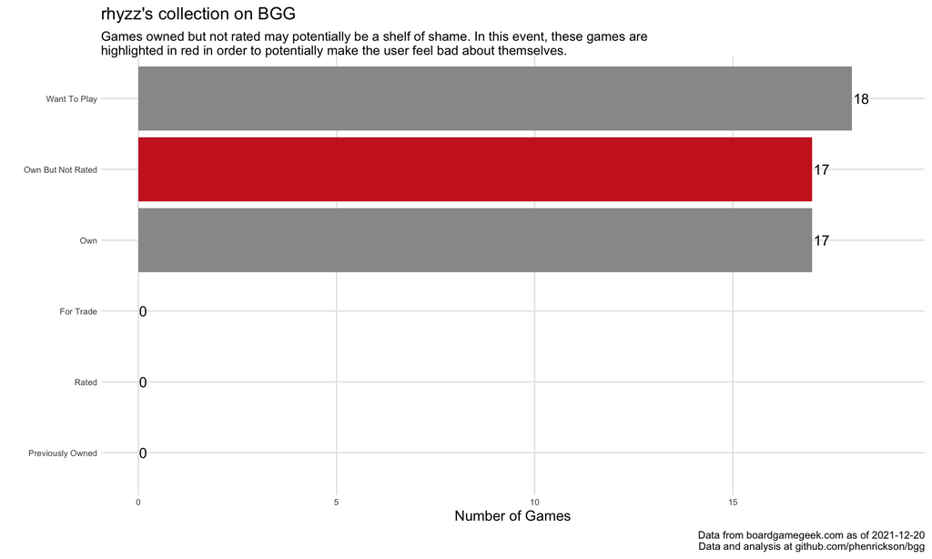

What years has the user owned/rated games from? While we can’t see when a user added or removed a game from their collection, we can look at their collection by the years in which their games were published.

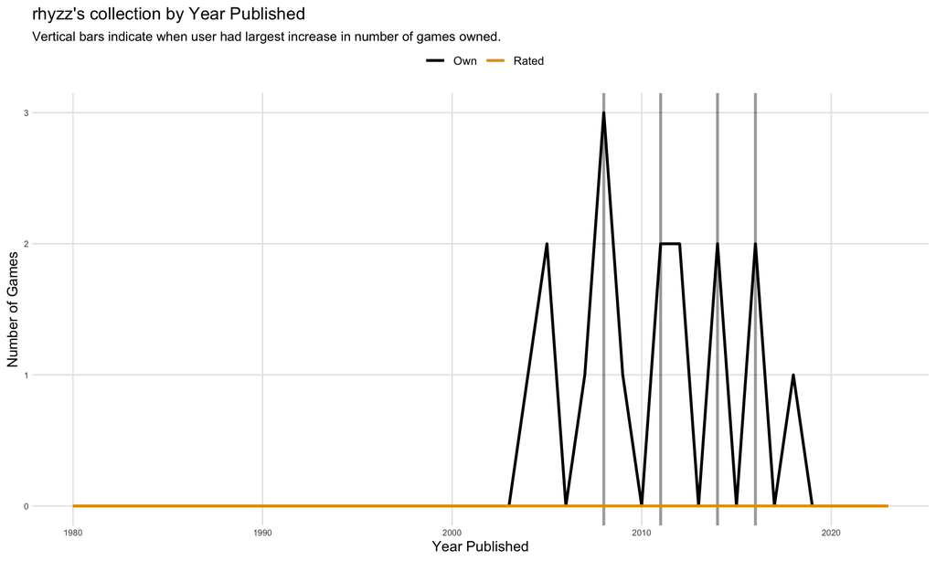

## 1.1 What types of games does rhyzz own?

We can look at the most frequent types of categories, mechanics, designers, and artists that appear in a user’s collection.

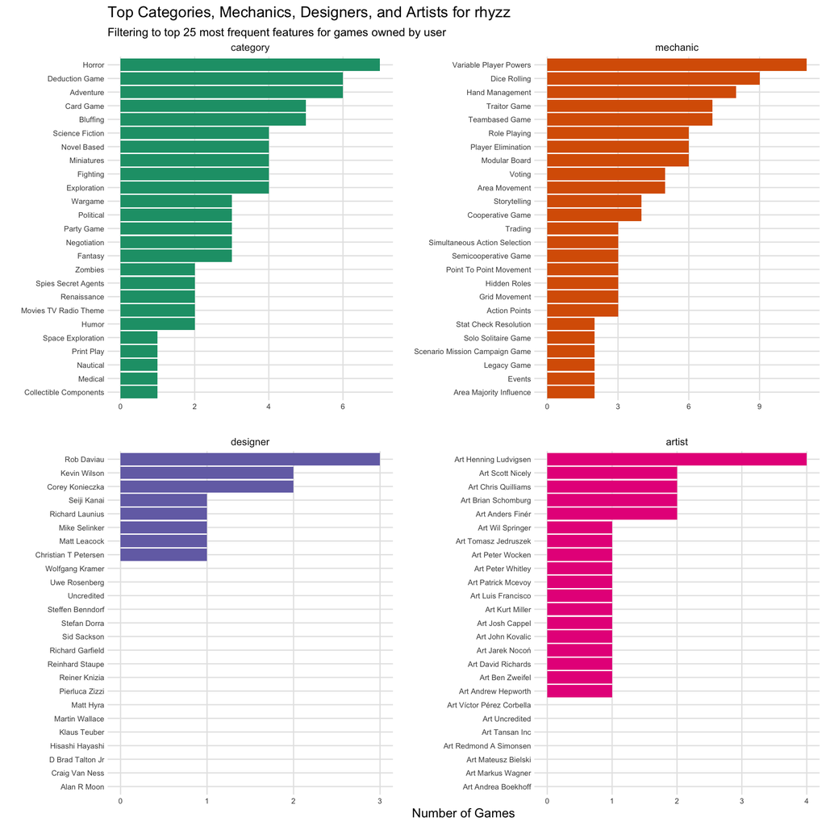

# 2 Modeling **rhyzz’s** Collection

| username | dataset | period | games_owned | games_rated | games_played |
| --- | --- | --- | --- | --- | --- |
| rhyzz | training | published before 2018 | 15 | 0 | 15 |
| rhyzz | test | published 2018 or later | 1 | 0 | 1 |

There are two main (binary) outcomes we will be modeling for the user.

The first, **own** refers to whether the user currently lists a game as owned in their collection. The second, **played** refers to whether the user currently owns, has rated, or previously owned a game. This means the latter will generally have a larger list of games, but may still be a useful category to examine for people who play lots of games without necessarily owning them.

We will train predictive models to learn the probability that the user will own or play individual games based on their features.

## 2.1 Coefficients for rhyzz

We can examine coefficients from the trained modes, which are penalized logistic regressions fit to our two main outcomes. Positive values indicate that a feature increases a user’s probabilility of owning/rating a game, while negative values indicate a feature decreases the probability.

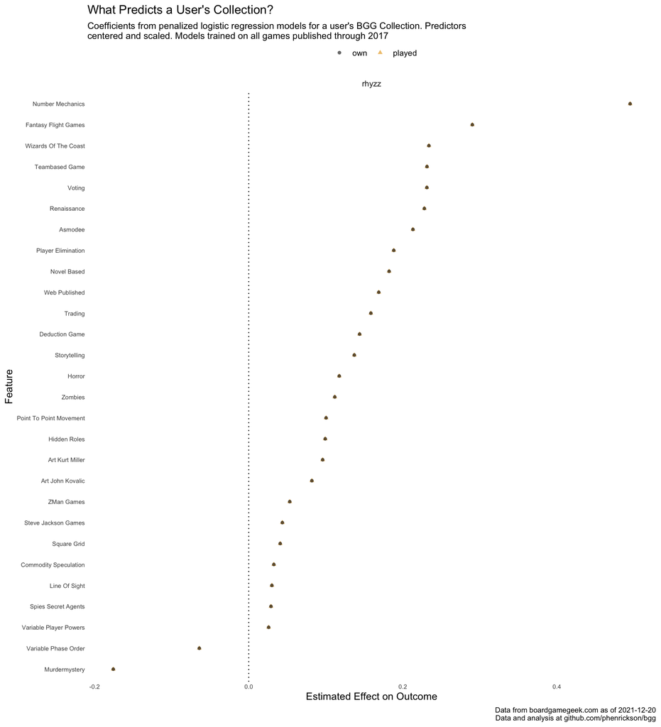

## 2.2 Visualizing Predictors for rhyzz’s Collection

Why did the model identify these features? We can make density plots of the important features for predicting whether the user owned a game. Blue indicates the density for games owned by the user, while grey indicates the density for games not owned by the user.

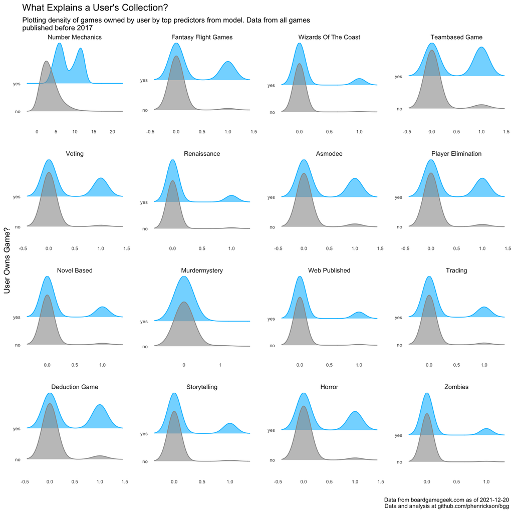

Binary predictors can be difficult to see with this visualization, so we can also directly examine the percentage of games in a user’s collection with a predictor vs the percentage of all games with that predictor.

| username | Feature | % of Games with Feature In_Collection | % of Games with Feature All_Games | Ratio |
| --- | --- | --- | --- | --- |
| rhyzz | Hidden Roles | 20.0% | 0.7% | 29.1 |
| rhyzz | Wizards Of The Coast | 13.3% | 0.7% | 19.0 |
| rhyzz | Voting | 33.3% | 2.5% | 13.5 |
| rhyzz | Fantasy Flight Games | 33.3% | 2.9% | 11.7 |
| rhyzz | Storytelling | 20.0% | 1.8% | 11.1 |
| rhyzz | Zombies | 13.3% | 1.2% | 10.9 |
| rhyzz | Spies Secret Agents | 13.3% | 1.3% | 10.0 |
| rhyzz | Horror | 33.3% | 3.7% | 9.1 |
| rhyzz | Player Elimination | 33.3% | 4.1% | 8.1 |
| rhyzz | Web Published | 13.3% | 1.7% | 7.7 |
| rhyzz | Teambased Game | 46.7% | 6.2% | 7.5 |
| rhyzz | Novel Based | 20.0% | 2.8% | 7.2 |
| rhyzz | Deduction Game | 40.0% | 6.0% | 6.7 |
| rhyzz | Renaissance | 13.3% | 2.0% | 6.5 |
| rhyzz | Asmodee | 33.3% | 5.2% | 6.4 |
| rhyzz | Line Of Sight | 6.7% | 1.1% | 6.0 |
| rhyzz | Trading | 20.0% | 3.4% | 5.8 |
| rhyzz | Steve Jackson Games | 6.7% | 1.2% | 5.3 |
| rhyzz | Square Grid | 6.7% | 1.4% | 4.6 |
| rhyzz | Variable Player Powers | 66.7% | 15.7% | 4.3 |
| rhyzz | Point To Point Movement | 20.0% | 5.2% | 3.9 |
| rhyzz | Commodity Speculation | 6.7% | 1.9% | 3.6 |
| rhyzz | ZMan Games | 13.3% | 3.8% | 3.5 |
| rhyzz | Murdermystery | 0.0% | 1.6% | 0.0 |
| rhyzz | Variable Phase Order | 0.0% | 2.1% | 0.0 |

# 3 Assess Model’s Performance on Training Set

Before predicting games in upcoming years, we can examine how well the model did and what games it liked in the training set. In this case, we used resampling techniques (cross validation) to ensure that the model had not seen a game before making its predictions.

## 3.1 Separation Plot

An easy way to examine the performance of classification model is to view a separation plot. We plot the predicted probabilities from the model for every game (from resampling) from lowest to highest. We then overlay a blue line for any game that the user does own. A good classifier is one that is able to *separate* the blue (games owned by the user) from the white (games not owned by the user), with most of the blue occurring at the highest probabilities (right side of the chart).

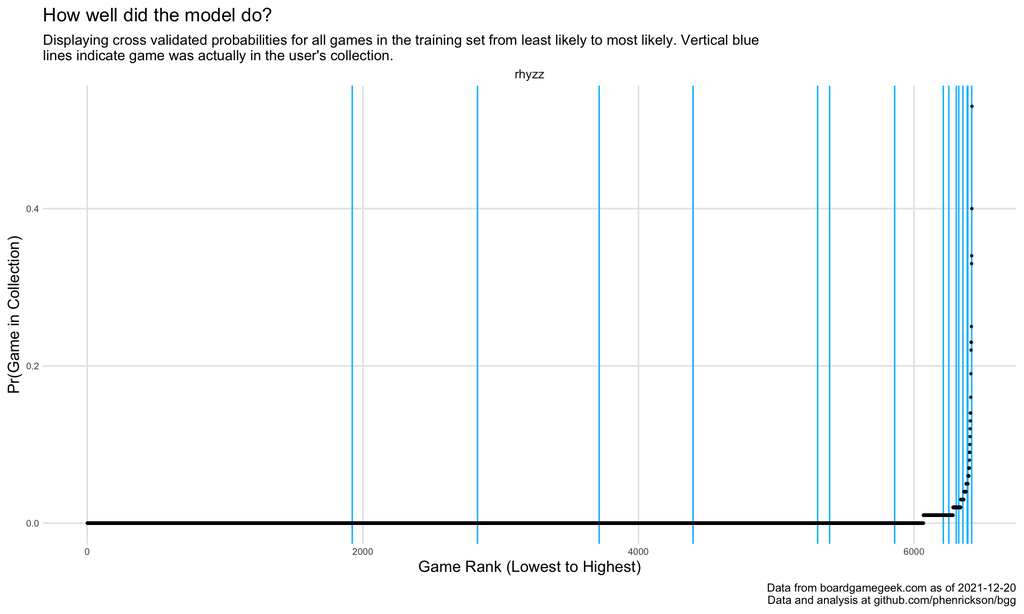

## 3.2 Top Games for **rhyzz** from Training Set

We can display this information in table form, displaying the 100 games with the highest probability of ownership, adding a blue line when the user does own the game.

| username | yearpublished | game_id | name | pred_played | pred_own | actual_played | actual_own |
| --- | --- | --- | --- | --- | --- | --- | --- |
| rhyzz | 2017 | 233078 | Twilight Imperium: Fourth Edition | 0.53 | 0.53 | 0 | 0 |
| rhyzz | 2005 | 12493 | Twilight Imperium: Third Edition | 0.40 | 0.40 | 0 | 0 |
| rhyzz | 2008 | 37111 | Battlestar Galactica: The Board Game | 0.34 | 0.34 | 1 | 1 |
| rhyzz | 1986 | 925 | Werewolf | 0.33 | 0.33 | 0 | 0 |
| rhyzz | 2000 | 823 | The Lord of the Rings | 0.25 | 0.25 | 0 | 0 |
| rhyzz | 2017 | 228660 | Betrayal at Baldur's Gate | 0.23 | 0.23 | 0 | 0 |
| rhyzz | 2016 | 193037 | Dead of Winter: The Long Night | 0.23 | 0.23 | 0 | 0 |
| rhyzz | 2010 | 73171 | Earth Reborn | 0.22 | 0.22 | 0 | 0 |
| rhyzz | 2000 | 478 | Citadels | 0.19 | 0.19 | 0 | 0 |
| rhyzz | 2012 | 104162 | Descent: Journeys in the Dark (Second Edition) | 0.16 | 0.16 | 0 | 0 |
| rhyzz | 2013 | 143741 | BANG! The Dice Game | 0.14 | 0.14 | 0 | 0 |
| rhyzz | 2012 | 128882 | The Resistance: Avalon | 0.14 | 0.14 | 0 | 0 |
| rhyzz | 2017 | 174430 | Gloomhaven | 0.13 | 0.13 | 0 | 0 |
| rhyzz | 2015 | 175549 | Salem 1692 | 0.12 | 0.12 | 0 | 0 |
| rhyzz | 2013 | 127024 | Room 25 | 0.11 | 0.11 | 0 | 0 |
| rhyzz | 2016 | 205716 | New Angeles | 0.10 | 0.10 | 0 | 0 |
| rhyzz | 2012 | 122599 | Winter Tales | 0.09 | 0.09 | 0 | 0 |
| rhyzz | 2005 | 16772 | Mall of Horror | 0.09 | 0.09 | 0 | 0 |
| rhyzz | 2015 | 175878 | 504 | 0.08 | 0.08 | 0 | 0 |
| rhyzz | 2009 | 56885 | The Werewolves of Miller's Hollow: The Village | 0.07 | 0.07 | 0 | 0 |
| rhyzz | 2008 | 38159 | Ultimate Werewolf: Ultimate Edition | 0.07 | 0.07 | 0 | 0 |
| rhyzz | 2014 | 152241 | Ultimate Werewolf | 0.07 | 0.07 | 0 | 0 |
| rhyzz | 2010 | 65200 | Asteroyds | 0.07 | 0.07 | 0 | 0 |
| rhyzz | 2012 | 104710 | Wiz-War (Eighth Edition) | 0.06 | 0.06 | 0 | 0 |
| rhyzz | 2014 | 153064 | Good Cop Bad Cop | 0.06 | 0.06 | 0 | 0 |
| rhyzz | 2007 | 32471 | Mafia | 0.06 | 0.06 | 0 | 0 |
| rhyzz | 2014 | 158392 | Stay Away! | 0.06 | 0.06 | 0 | 0 |
| rhyzz | 2002 | 3955 | BANG! | 0.06 | 0.06 | 0 | 0 |
| rhyzz | 2003 | 6472 | A Game of Thrones | 0.06 | 0.06 | 0 | 0 |
| rhyzz | 2011 | 91872 | Dungeons & Dragons: The Legend of Drizzt Board Game | 0.06 | 0.06 | 0 | 0 |

[output cut: 70 more lines]

We can also more formally assess how well the model did in resampling by looking at the area under the receiver operating characteristic. A perfect model would receive a score of 1, while a model that cannot predict the outcome will default to a score of 0.5. The extent to which something is a *good* score depends on the setting, but generally anything in the .8 to .9 range is very good while the .7 to .8 range is perfectly acceptable.

| username | outcome_type | .metric | .estimator | .estimate |
| --- | --- | --- | --- | --- |
| rhyzz | own | roc_auc | binary | 0.918 |
| rhyzz | played | roc_auc | binary | 0.918 |

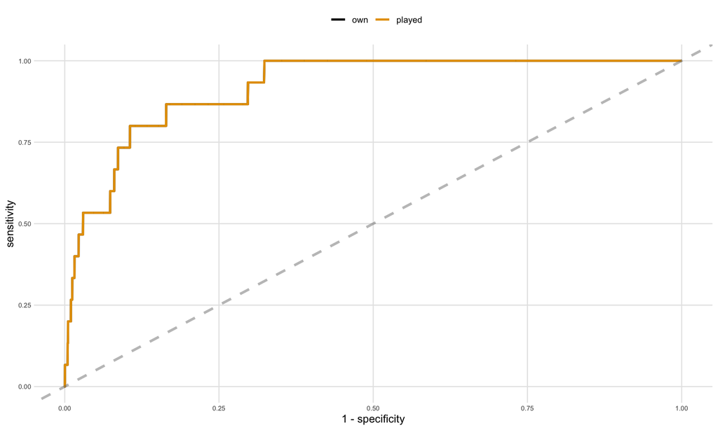

Another way to think about the model performance is to view its lift, or its ability to detect the positive outcomes over that of a null model. High lift indicates the model can much more quickly find all of the positive outcomes (in this case, games owned or played by the user), while a model with no lift is no better than random guessing.

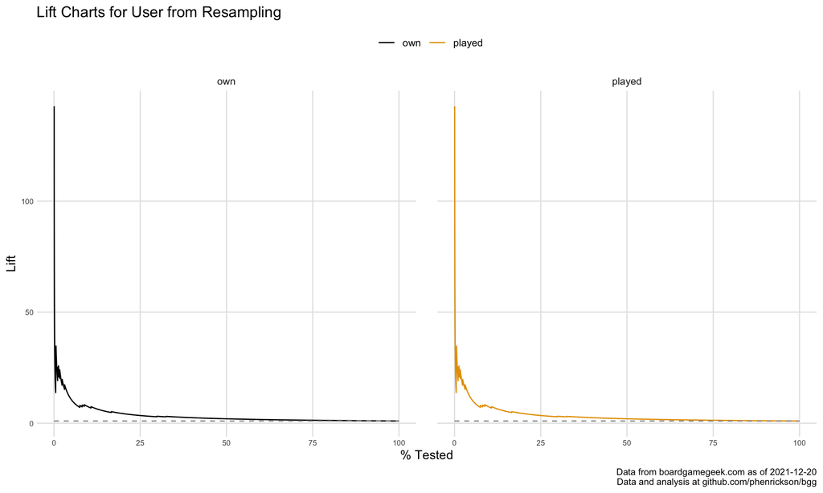

## 3.3 Most and Least Likely Games

What games does the model think rhyzz is **most likely to own** that are **not** in their collection?

| username | yearpublished | game_id | name | pred_own | actual_own |
| --- | --- | --- | --- | --- | --- |
| rhyzz | 2017 | 233078 | Twilight Imperium: Fourth Edition | 0.53 | 0 |
| rhyzz | 2005 | 12493 | Twilight Imperium: Third Edition | 0.40 | 0 |
| rhyzz | 1986 | 925 | Werewolf | 0.33 | 0 |
| rhyzz | 2000 | 823 | The Lord of the Rings | 0.25 | 0 |
| rhyzz | 2017 | 228660 | Betrayal at Baldur's Gate | 0.23 | 0 |

What games does the model think rhyzz is **least likely to own** that **are** in their collection?

| username | yearpublished | game_id | name | pred_own | actual_own |
| --- | --- | --- | --- | --- | --- |
| rhyzz | 2008 | 30549 | Pandemic | 0 | 1 |
| rhyzz | 2012 | 129622 | Love Letter | 0 | 1 |
| rhyzz | 2007 | 29368 | Last Night on Earth: The Zombie Game | 0 | 1 |
| rhyzz | 2008 | 39856 | Dixit | 0 | 1 |
| rhyzz | 2011 | 105134 | Risk Legacy | 0 | 1 |

## 3.4 Top Games by Year

Top 25 games most likely to be owned by the user in each year, highlighting in blue the games that the user has owned/played.

| rank | 2009 | 2010 | 2011 | 2012 | 2013 | 2014 | 2015 | 2016 | 2017 |
| --- | --- | --- | --- | --- | --- | --- | --- | --- | --- |
| 1 | The Werewolves of Miller's Hollow: The Village | Earth Reborn | Dungeons & Dragons: The Legend of Drizzt Board Game | Descent: Journeys in the Dark (Second Edition) | BANG! The Dice Game | Ultimate Werewolf | Salem 1692 | Dead of Winter: The Long Night | Twilight Imperium: Fourth Edition |
| 2 | Middle-Earth Quest | Asteroyds | The Walking Dead: The Board Game | The Resistance: Avalon | Room 25 | Good Cop Bad Cop | 504 | New Angeles | Betrayal at Baldur's Gate |
| 3 | Axis & Allies Pacific 1940 | The Hobbit | Alcatraz: The Scapegoat | Winter Tales | Eldritch Horror | Stay Away! | One Night Revolution | When I Dream | Gloomhaven |
| 4 | The Resistance | Cyrano | Dark Moon | Wiz-War (Eighth Edition) | Carnival Zombie | Dead of Winter: A Crossroads Game | Bang! The Dice Game: The Walking Dead | Game of Thrones: The Iron Throne | A Game of Thrones: Catan – Brotherhood of the Watch |
| 5 | Chaos in the Old World | Sid Meier's Civilization: The Board Game | Dungeons & Dragons: Wrath of Ashardalon Board Game | One Night Werewolf | A Study in Emerald | DungeonQuest Revised Edition | One Night Ultimate Werewolf: Daybreak | Hit Z Road | Fallout |
| 6 | Axis & Allies: 1942 | Escape from the Aliens in Outer Space | Ventura | Exodus: Proxima Centauri | Where Art Thou Romeo? | Legendary Encounters: An Alien Deck Building Game | One Night Ultimate Vampire | Magic: The Gathering – Arena of the Planeswalkers: Shadows over Innistrad | This War of Mine: The Board Game |
| 7 | Claustrophobia | Mousquetaires du Roy | Gears of War: The Board Game | Dixit: Journey | Huida de Silver City | One Night Ultimate Werewolf | A Study in Emerald (Second Edition) | Star Wars: Rebellion | The Thing: Infection at Outpost 31 |
| 8 | Age of Conan: The Strategy Board Game | Dungeons & Dragons: Castle Ravenloft Board Game | Battleship Galaxies | Lords of Waterdeep | Patchistory | Patchwork | Chaosmos | Insider | Tortuga 1667 |
| 9 | Opera | Labyrinth: The War on Terror, 2001 – ? | Discworld: Ankh-Morpork | Serenissima (Second Edition) | Axis & Allies: WWI 1914 | Sons of Anarchy: Men of Mayhem | Burgle Bros. | Secret Hitler | Mythic Battles: Pantheon |
| 10 | Wings of War: WW2 Deluxe set | Heroscape Master Set: Battle for the Underdark | Pastiche | Robinson Crusoe: Adventures on the Cursed Island | Ultimate Werewolf: Inquisition | The Walled City: Londonderry & Borderlands | Dungeons & Dragons: Temple of Elemental Evil Board Game | The Others | The Chameleon |
| 11 | Ugg-Tect | Battle Cry: 150th Civil War Anniversary Edition | Dungeons & Dragons: Conquest of Nerath Board Game | City of Horror | Two Rooms and a Boom | The Witcher Adventure Game | T.I.M.E Stories | Smash Up: It's Your Fault! | One Night Ultimate Alien |
| 12 | Luna Llena: Full Moon | Battles of Westeros | Mage Knight Board Game | Dungeon Command: Sting of Lolth | Level 7 [Omega Protocol] | Ultimate Werewolf: Deluxe Edition | Above and Below | Tyrants of the Underdark | Black Sonata |
| 13 | Party Alias | Escape of the Dead Minigame | Resident Evil Deck Building Game: Alliance | Dungeon Command: Heart of Cormyr | LEADERS: The Combined Strategy Game | Ca$h 'n Guns (Second Edition) | Runebound (Third Edition) | Clank!: A Deck-Building Adventure | A Column of Fire |
| 14 | Masters of Venice | DungeonQuest (Third Edition) | Elder Sign | Game of Thrones: The Card Game | Tash-Kalar: Arena of Legends | Spyfall | Pandemic Legacy: Season 1 | Pandemic: Reign of Cthulhu | Clank! In! Space!: A Deck-Building Adventure |
| 15 | Ad Astra | Zombie Survival: The Board Game | Dixit: Odyssey | Agents of SMERSH | Mayday!Mayday! | Deception: Murder in Hong Kong | Warhammer Quest: The Adventure Card Game | Archer: Once You Go Blackmail... | Pendragon: The Fall of Roman Britain |
| 16 | The Three Musketeers: The Queen's Pendants | Masques | Letters from Whitechapel | War of the Ring: Second Edition | Antidote | BANG!: The Walking Dead | Cthulhu Realms | Forged in Steel | Whitehall Mystery |
| 17 | Name 5 | Nuns on the Run | Eclipse | Zombicide | Impulse | Pictopia: Disney Edition | Heroes | Cry Havoc | Pandemic Legacy: Season 2 |
| 18 | Waterloo | Zombie in My Pocket | Dungeon Fighter | Coup | Ladies & Gentlemen | [redacted] | M.U.L.E. The Board Game | Santorini | Azul |
| 19 | The Caucasus Campaign | Dominant Species | A Game of Thrones: The Board Game (Second Edition) | Axis & Allies 1941 | Risk: The Walking Dead – Survival Edition | Billionaire Banshee | Unusual Suspects | Captain Sonar | Spirit Island |
| 20 | Grind | Three-Dragon Ante: Emperor's Gambit | Flash Point: Fire Rescue | Dungeon Command: Curse of Undeath | Dungeon Command: Blood of Gruumsh | Templar Intrigue | Steampunk Rally | Crazy Karts | Abandon Planet |
| 21 | Dungeon Twister 2: Prison | Ultimate Werewolf: Compact Edition | Fief | Mice and Mystics | Band of Brothers: Ghost Panzer | Dogs of War | Unspeakable Words: Deluxe Edition | Citadels | Breaking Bad: The Board Game |
| 22 | Space Hulk (Third Edition) | Catacombs | Mansions of Madness | Il Vecchio | BattleLore: Second Edition | Sheriff of Nottingham | Imagine | Timebomb | Dracula's Feast |
| 23 | Hellenes: Campaigns of the Peloponnesian War | Ranking | Band of Brothers: Screaming Eagles | Clash of Cultures | No Retreat!: The North African Front | Tiny Epic Kingdoms | Dune: The Dice Game | Burke's Gambit | Muse |
| 24 | The Halls of Montezuma | Nations at War: White Star Rising | A Few Acres of Snow | Merchant of Venus (Second Edition) | Crusade and Revolution: The Spanish Civil War, 1936-1939 | Fallen | Codenames | Codenames: Pictures | Summit: The Board Game |
| 25 | A Victory Denied: Crisis at Smolensk, July-September, 1941 | Battles of Napoleon: The Eagle and the Lion | Sekigahara: The Unification of Japan | Smash Up | Sedition Wars: Battle for Alabaster | Holdfast: Russia 1941-42 | Alien vs Predator: The Hunt Begins | Codenames: Deep Undercover | Here I Stand: 500th Anniversary Edition |

## 3.5 Interactive Predictions from Resampling

Interactive table for predictions from resampling.

|  | username | yearpublished | rank | game_id | name | pred_played | pred_own | actual_played | actual_own |
| --- | --- | --- | --- | --- | --- | --- | --- | --- | --- |
| 1 | rhyzz | 1900 | 85 | 171 | Chess | 0.02 | 0.02 | 0 | 0 |
| 2 | rhyzz | 1900 | 367 | 5546 | Marbles | 0 | 0 | 0 | 0 |
| 3 | rhyzz | 1900 | 370 | 11901 | Tic-Tac-Toe | 0 | 0 | 0 | 0 |
| 4 | rhyzz | 1900 | 415 | 188 | Go | 0 | 0 | 0 | 0 |
| 5 | rhyzz | 1900 | 532 | 2065 | Shogi | 0 | 0 | 0 | 0 |
| 6 | rhyzz | 1900 | 534 | 2393 | Xiangqi | 0 | 0 | 0 | 0 |
| 7 | rhyzz | 1900 | 733 | 26952 | International Checkers | 0 | 0 | 0 | 0 |
| 8 | rhyzz | 1900 | 763 | 1602 | The Royal Game of Ur | 0 | 0 | 0 | 0 |
| 9 | rhyzz | 1900 | 764 | 2083 | Checkers | 0 | 0 | 0 | 0 |
| 10 | rhyzz | 1900 | 772 | 2389 | Othello | 0 | 0 | 0 | 0 |

[output cut: 6410 more lines]

# 4 Validating the Model on 2018

How well did a model trained on a user’s collection through 2017 perform in predicting games for the user from 2018?

| username | outcome_type | yearpublished | .metric | .estimator | .estimate |
| --- | --- | --- | --- | --- | --- |
| rhyzz | own | 2018 | roc_auc | binary | 0.983 |
| rhyzz | played | 2018 | roc_auc | binary | 0.983 |

Table of top 25 games from 2018, highlighting games that the user owns.

| username | yearpublished | game_id | name | pred_own | pred_played | actual_own | actual_played |
| --- | --- | --- | --- | --- | --- | --- | --- |
| rhyzz | 2018 | 167355 | Nemesis | 0.08 | 0.08 | 0 | 0 |
| rhyzz | 2018 | 257499 | Arkham Horror (Third Edition) | 0.08 | 0.08 | 0 | 0 |
| rhyzz | 2018 | 242639 | Treasure Island | 0.04 | 0.04 | 0 | 0 |
| rhyzz | 2018 | 246960 | Axis & Allies & Zombies | 0.04 | 0.04 | 0 | 0 |
| rhyzz | 2018 | 257321 | Gen7: A Crossroads Game | 0.04 | 0.04 | 0 | 0 |
| rhyzz | 2018 | 192296 | The Pirate Republic | 0.03 | 0.03 | 0 | 0 |
| rhyzz | 2018 | 252328 | Star Wars: X-Wing (Second Edition) | 0.03 | 0.03 | 0 | 0 |
| rhyzz | 2018 | 240196 | Betrayal Legacy | 0.02 | 0.02 | 1 | 1 |
| rhyzz | 2018 | 244536 | Tiny Epic Zombies | 0.02 | 0.02 | 0 | 0 |
| rhyzz | 2018 | 256788 | Detective Club | 0.02 | 0.02 | 0 | 0 |
| rhyzz | 2018 | 313010 | Cosmic Encounter: 42nd Anniversary Edition | 0.02 | 0.02 | 0 | 0 |
| rhyzz | 2018 | 170604 | Renegade | 0.01 | 0.01 | 0 | 0 |
| rhyzz | 2018 | 171964 | The Order of Vampire Hunters | 0.01 | 0.01 | 0 | 0 |
| rhyzz | 2018 | 205477 | Vengeance | 0.01 | 0.01 | 0 | 0 |
| rhyzz | 2018 | 205896 | Rising Sun | 0.01 | 0.01 | 0 | 0 |
| rhyzz | 2018 | 207243 | The City of Kings | 0.01 | 0.01 | 0 | 0 |
| rhyzz | 2018 | 209324 | The World of SMOG: Rise of Moloch | 0.01 | 0.01 | 0 | 0 |
| rhyzz | 2018 | 214032 | Founders of Gloomhaven | 0.01 | 0.01 | 0 | 0 |
| rhyzz | 2018 | 224710 | Zombicide: Green Horde | 0.01 | 0.01 | 0 | 0 |
| rhyzz | 2018 | 225167 | Human Punishment: Social Deduction 2.0 | 0.01 | 0.01 | 0 | 0 |
| rhyzz | 2018 | 225694 | Decrypto | 0.01 | 0.01 | 0 | 0 |
| rhyzz | 2018 | 226176 | Fallout: Wasteland Warfare | 0.01 | 0.01 | 0 | 0 |
| rhyzz | 2018 | 235544 | Specter Ops: Broken Covenant | 0.01 | 0.01 | 0 | 0 |
| rhyzz | 2018 | 245422 | Werewords Deluxe Edition | 0.01 | 0.01 | 0 | 0 |
| rhyzz | 2018 | 246297 | Shadows: Amsterdam | 0.01 | 0.01 | 0 | 0 |

# 5 Predicting Upcoming Games (2018 and On) for **rhyzz**

Examine the top games for the test set.

| username | yearpublished | game_id | name | rank | own | played |
| --- | --- | --- | --- | --- | --- | --- |
| rhyzz | 2018 | 167355 | Nemesis | 1 | 0.08 | 0.08 |
| rhyzz | 2018 | 257499 | Arkham Horror (Third Edition) | 2 | 0.08 | 0.08 |
| rhyzz | 2018 | 257321 | Gen7: A Crossroads Game | 3 | 0.04 | 0.04 |
| rhyzz | 2018 | 246960 | Axis & Allies & Zombies | 4 | 0.04 | 0.04 |
| rhyzz | 2018 | 242639 | Treasure Island | 5 | 0.04 | 0.04 |
| rhyzz | 2018 | 252328 | Star Wars: X-Wing (Second Edition) | 6 | 0.03 | 0.03 |
| rhyzz | 2018 | 192296 | The Pirate Republic | 7 | 0.03 | 0.03 |
| rhyzz | 2018 | 244536 | Tiny Epic Zombies | 8 | 0.02 | 0.02 |
| rhyzz | 2018 | 240196 | Betrayal Legacy | 9 | 0.02 | 0.02 |
| rhyzz | 2018 | 313010 | Cosmic Encounter: 42nd Anniversary Edition | 10 | 0.02 | 0.02 |
| rhyzz | 2018 | 256788 | Detective Club | 11 | 0.02 | 0.02 |
| rhyzz | 2018 | 258244 | Discover: Lands Unknown | 12 | 0.01 | 0.01 |
| rhyzz | 2018 | 207243 | The City of Kings | 13 | 0.01 | 0.01 |
| rhyzz | 2018 | 246297 | Shadows: Amsterdam | 14 | 0.01 | 0.01 |
| rhyzz | 2018 | 225694 | Decrypto | 15 | 0.01 | 0.01 |
| rhyzz | 2018 | 171964 | The Order of Vampire Hunters | 16 | 0.01 | 0.01 |
| rhyzz | 2018 | 226176 | Fallout: Wasteland Warfare | 17 | 0.01 | 0.01 |
| rhyzz | 2018 | 260428 | Pandemic: Fall of Rome | 18 | 0.01 | 0.01 |
| rhyzz | 2018 | 170604 | Renegade | 19 | 0.01 | 0.01 |
| rhyzz | 2018 | 205477 | Vengeance | 20 | 0.01 | 0.01 |
| rhyzz | 2018 | 209324 | The World of SMOG: Rise of Moloch | 21 | 0.01 | 0.01 |
| rhyzz | 2018 | 251420 | Choose Your Own Adventure: House of Danger | 22 | 0.01 | 0.01 |
| rhyzz | 2018 | 214032 | Founders of Gloomhaven | 23 | 0.01 | 0.01 |
| rhyzz | 2018 | 224710 | Zombicide: Green Horde | 24 | 0.01 | 0.01 |
| rhyzz | 2018 | 252197 | One Week Ultimate Werewolf | 25 | 0.01 | 0.01 |
| rhyzz | 2019 | 269385 | The Lord of the Rings: Journeys in Middle-Earth | 1 | 0.06 | 0.06 |
| rhyzz | 2019 | 266507 | Clank!: Legacy – Acquisitions Incorporated | 2 | 0.03 | 0.03 |
| rhyzz | 2019 | 239472 | Abomination: The Heir of Frankenstein | 3 | 0.02 | 0.02 |
| rhyzz | 2019 | 285984 | Last Bastion | 4 | 0.02 | 0.02 |
| rhyzz | 2019 | 271896 | Star Wars: Outer Rim | 5 | 0.02 | 0.02 |
| rhyzz | 2019 | 245655 | The King's Dilemma | 6 | 0.02 | 0.02 |
| rhyzz | 2019 | 274637 | Unmatched: Battle of Legends, Volume One | 7 | 0.02 | 0.02 |
| rhyzz | 2019 | 264806 | We're Doomed! | 8 | 0.01 | 0.01 |
| rhyzz | 2019 | 299121 | Machina Arcana (Second/Third Edition) | 9 | 0.01 | 0.01 |
| rhyzz | 2019 | 155065 | Lifeform | 10 | 0.01 | 0.01 |
| rhyzz | 2019 | 283355 | Dune | 11 | 0.01 | 0.01 |
| rhyzz | 2019 | 283863 | The Magnificent | 12 | 0.01 | 0.01 |
| rhyzz | 2019 | 169427 | Middara: Unintentional Malum – Act 1 | 13 | 0.01 | 0.01 |
| rhyzz | 2019 | 239942 | Black Rose Wars | 14 | 0.01 | 0.01 |
| rhyzz | 2019 | 267652 | Dungeonology: The Expedition | 15 | 0.01 | 0.01 |
| rhyzz | 2019 | 265684 | Subtext | 16 | 0.01 | 0.01 |
| rhyzz | 2019 | 249746 | Nanty Narking | 17 | 0.01 | 0.01 |
| rhyzz | 2019 | 279613 | Unlock!: Timeless Adventures | 18 | 0.01 | 0.01 |
| rhyzz | 2019 | 253635 | Ragusa | 19 | 0.01 | 0.01 |
| rhyzz | 2019 | 252854 | Sabotage | 20 | 0.01 | 0.01 |
| rhyzz | 2019 | 219217 | Arena: The Contest | 21 | 0.01 | 0.01 |
| rhyzz | 2019 | 271754 | Spire's End | 22 | 0.01 | 0.01 |
| rhyzz | 2019 | 278297 | Choose Your Own Adventure: War with the Evil Power Master | 23 | 0.01 | 0.01 |
| rhyzz | 2019 | 274638 | Unmatched: Robin Hood vs. Bigfoot | 24 | 0.01 | 0.01 |
| rhyzz | 2019 | 295564 | Unmatched Game System | 25 | 0.01 | 0.01 |
| rhyzz | 2020 | 292333 | Cowboys II: Cowboys & Indians Edition | 1 | 0.05 | 0.05 |
| rhyzz | 2020 | 261403 | Inhuman Conditions | 2 | 0.04 | 0.04 |
| rhyzz | 2020 | 313817 | Hello Neighbor: The Secret Neighbor Party Game | 3 | 0.04 | 0.04 |
| rhyzz | 2020 | 294484 | Unmatched: Cobble & Fog | 4 | 0.04 | 0.04 |
| rhyzz | 2020 | 291457 | Gloomhaven: Jaws of the Lion | 5 | 0.03 | 0.03 |
| rhyzz | 2020 | 307997 | Insider Black | 6 | 0.03 | 0.03 |
| rhyzz | 2020 | 296892 | Sacred Rites | 7 | 0.02 | 0.02 |
| rhyzz | 2020 | 295687 | Trust Me, I'm a Doctor | 8 | 0.02 | 0.02 |
| rhyzz | 2020 | 313850 | Escape The Night: The Board Game | 9 | 0.02 | 0.02 |
| rhyzz | 2020 | 284665 | Board Royale: The Island | 10 | 0.02 | 0.02 |
| rhyzz | 2020 | 295577 | Dungeon Mayhem: Monster Madness | 11 | 0.02 | 0.02 |
| rhyzz | 2020 | 263894 | Grind House | 12 | 0.02 | 0.02 |
| rhyzz | 2020 | 245025 | Paradise Lost | 13 | 0.01 | 0.01 |
| rhyzz | 2020 | 294788 | Conqueror: Final Conquest | 14 | 0.01 | 0.01 |
| rhyzz | 2020 | 236861 | Full Moon Jacket | 15 | 0.01 | 0.01 |
| rhyzz | 2020 | 304285 | Infinity Gauntlet: A Love Letter Game | 16 | 0.01 | 0.01 |
| rhyzz | 2020 | 327913 | Unlock!: Timeless Adventures – Arsène Lupin und der große weiße Diamant | 17 | 0.01 | 0.01 |
| rhyzz | 2020 | 314040 | Pandemic Legacy: Season 0 | 18 | 0.01 | 0.01 |
| rhyzz | 2020 | 304434 | Victim: The Cursed Forest | 19 | 0.01 | 0.01 |
| rhyzz | 2020 | 303552 | Magic: The Gathering – Unsanctioned | 20 | 0.01 | 0.01 |
| rhyzz | 2020 | 282922 | Windward | 21 | 0.01 | 0.01 |
| rhyzz | 2020 | 262274 | D6: Dungeons, Dudes, Dames, Danger, Dice and Dragons! | 22 | 0.01 | 0.01 |
| rhyzz | 2020 | 325611 | Runes of Zun | 23 | 0.01 | 0.01 |
| rhyzz | 2020 | 315196 | Dungeons & Dragons: Adventure Begins | 24 | 0.01 | 0.01 |
| rhyzz | 2020 | 302809 | Betrayal at Mystery Mansion | 25 | 0.01 | 0.01 |

## 5.1 Interactive Table for Upcoming Games 2018 and On

|  | username | yearpublished | game_id | name | rank | own | played |
| --- | --- | --- | --- | --- | --- | --- | --- |
| 1 | rhyzz | 2018 | 167355 | Nemesis | 1 | 0.08 | 0.08 |
| 2 | rhyzz | 2018 | 257499 | Arkham Horror (Third Edition) | 2 | 0.08 | 0.08 |
| 3 | rhyzz | 2019 | 269385 | The Lord of the Rings: Journeys in Middle-Earth | 3 | 0.06 | 0.06 |
| 4 | rhyzz | 2020 | 292333 | Cowboys II: Cowboys &amp; Indians Edition | 4 | 0.05 | 0.05 |
| 5 | rhyzz | 2020 | 261403 | Inhuman Conditions | 5 | 0.04 | 0.04 |
| 6 | rhyzz | 2018 | 257321 | Gen7: A Crossroads Game | 6 | 0.04 | 0.04 |
| 7 | rhyzz | 2020 | 313817 | Hello Neighbor: The Secret Neighbor Party Game | 7 | 0.04 | 0.04 |
| 8 | rhyzz | 2018 | 246960 | Axis &amp; Allies &amp; Zombies | 8 | 0.04 | 0.04 |
| 9 | rhyzz | 2018 | 242639 | Treasure Island | 9 | 0.04 | 0.04 |
| 10 | rhyzz | 2020 | 294484 | Unmatched: Cobble &amp; Fog | 10 | 0.04 | 0.04 |

[output cut: 1923 more lines]